# OFH_task

- Show All Code
- Hide All Code
- View Source

Author

Matt Grant

**graph functions**

```r
library(tidyverse, quietly = TRUE)
library(broom)

daily_bookings_graph <-  function(data) {
  data |>
    ggplot(aes(x = day, y = daily_bookings, colour = clinic)) +
    geom_line() +
    geom_ribbon(aes(ymin = lower_daily_bookings, ymax = upper_daily_bookings, fill = clinic), line = NA, alpha = 0.12) +
    labs(
      title = "Daily bookings",
      x = "days since invitation",
      y = "bookings"
    )
}



# daily_bookings_graph(total_bookings)


cumul_bookings_graph <- function(data){
  data |>
    ggplot(aes(x = day, y = cumul_bookings, colour = clinic)) +
    geom_line() +
    geom_ribbon(aes(ymin = lower_cumul_bookings, ymax = upper_cumul_bookings, fill = clinic), line = NA, alpha = 0.12) +
    labs(
      title = "Total expected bookings",
      x = "days since invitation",
      y = "bookings"
    ) +
    geom_vline(xintercept = 35, linetype = "dashed", colour = "grey40") +
    annotate("text", x = 35, y = Inf, label = "Clinics open", vjust = 1.5, hjust = -0.1)
}

# cumul_bookings_graph(wave3_booking_curve)
```

**mailing info**

```r
C1_mailings <- tibble(
  type = c("NPL", "DT"),
  capacity = c(50000, 40000),
  convLow = c(0.015, 0.025),
  convHigh = c(0.03, 0.04)
   )

C1_mailings <- C1_mailings |>
  mutate(convMid = c((convLow + convHigh) / 2),
         capFilled = convMid * capacity,
         capFilledLow = convLow * capacity,
         capFilledHigh = convHigh * capacity) |>
   select(type, capacity, convLow, capFilledLow, convMid, capFilled, convHigh, capFilledHigh)

C2_mailings <- tibble(
  type = c("NPL", "DT"),
  capacity = c(80000, 5000),
  convLow = c(0.015, 0.025),
  convHigh = c(0.03, 0.04)
   )

C2_mailings <- C2_mailings |>
  mutate(convMid = c((convLow + convHigh) / 2),
         capFilled = convMid * capacity,
         capFilledLow = convLow * capacity,
         capFilledHigh = convHigh * capacity) |>
  select(type, capacity, convLow, capFilledLow, convMid, capFilled, convHigh, capFilledHigh)



# str_glue("Clinic 1 would have {sum(C1_mailings$capFilled)} people, while clinic 2 would have {sum(C2_mailings$capFilled)}")

C2_mailings$capacity <- c(90000, 5000)

C2_mailings <- C2_mailings |>
  mutate(capFilled = convMid * capacity,
         lowcapFilled = convLow * capacity)

C1_mailings$capacity <- c(40000, 40000)

C1_mailings <- C1_mailings |>
  mutate(capFilled = convMid * capacity,
         lowcapFilled = convLow * capacity)
# str_glue("Clinic 1 would have {sum(C1_mailings$capFilled)} people, while clinic 2 would have {sum(C2_mailings$capFilled)}")
# sum(C1_mailings$lowcapFilled)
# sum(C2_mailings$lowcapFilled)
```

**wave 1 code**

```r
DT_weibull_k      <- 0.7 # k < 1 so decreasing over time (rapid early bookings, slowing tail)
DT_weibull_lambda <- 2.5 # Higher lambda means bookings accumulate more slowly overall.

NPL_weibull_k      <- 0.5
NPL_weibull_lambda <- 3

days <- 0:63  # 5 weeks pre-clinic
w1_sends <- tibble(
  clinic    = c("clinic 1", "clinic 2"),
  mailing_type = c("NPL", "DT"),
  send_day  = c(8, 3),
  mailing_size = c(10000, 5000),
  conversion_rate = c(C1_mailings |> filter(type == "NPL") |> pull(convMid),
                      C2_mailings |> filter(type == "DT") |> pull(convMid)),
  lower_conversion_rate = c(C1_mailings |> filter(type == "NPL") |> pull(convLow),
                      C2_mailings |> filter(type == "DT") |> pull(convLow)),
  upper_conversion_rate = c(C1_mailings |> filter(type == "NPL") |> pull(convHigh),
                      C2_mailings |> filter(type == "DT") |> pull(convHigh))
)

wave1_booking_curve <- w1_sends |>
  expand_grid(day = 0:63) |>
  mutate(
    days_since_send = day - send_day,
    proportion = case_when(mailing_type == "NPL"
                                ~ pweibull(days_since_send, shape = NPL_weibull_k, scale = NPL_weibull_lambda),
                                mailing_type == "DT"
                                ~ pweibull(days_since_send, shape = DT_weibull_k, scale = DT_weibull_lambda)),
    cumul_bookings = proportion * mailing_size * conversion_rate,
    lower_cumul_bookings = proportion * mailing_size * lower_conversion_rate,
    upper_cumul_bookings = proportion * mailing_size * upper_conversion_rate
  ) |>
  mutate(
    daily_bookings = case_when(
      days_since_send == 0 ~ 0,
      days_since_send == 1 ~ cumul_bookings,
      .default = cumul_bookings - lag(cumul_bookings, n = 1)
    ),
    lower_daily_bookings = case_when(
      days_since_send == 0 ~ 0,
      days_since_send == 1 ~ lower_cumul_bookings,
      .default = lower_cumul_bookings - lag(lower_cumul_bookings, n = 1)
    ),
    upper_daily_bookings = case_when(
      days_since_send == 0 ~ 0,
      days_since_send == 1 ~ upper_cumul_bookings,
      .default = upper_cumul_bookings - lag(upper_cumul_bookings, n = 1)
    ),
    .by = clinic
  )
# wave1_booking_curve |> filter(proportion > .80 & proportion < .81)

# wave1_booking_curve |> daily_bookings_graph()

# wave1_booking_curve |> cumul_bookings_graph()
```

**wave 2 code**

```r
w2_sends <- tibble(
  clinic    = c("clinic 1", "clinic 2"),
  mailing_type = c("NPL", "NPL"),
  send_day  = c(17, 9),
  mailing_size = c(20000, 25000),
  conversion_rate = c(C1_mailings |> filter(type == "DT") |> pull(convMid),
                      C2_mailings |> filter(type == "NPL") |> pull(convMid)),
  lower_conversion_rate = c(C1_mailings |> filter(type == "DT") |> pull(convLow),
                            C2_mailings |> filter(type == "NPL") |> pull(convLow)),
  upper_conversion_rate = c(C1_mailings |> filter(type == "DT") |> pull(convHigh),
                            C2_mailings |> filter(type == "NPL") |> pull(convHigh))
)


wave2_booking_curve <- w2_sends |>
  expand_grid(day = 0:63) |>
  mutate(
    days_since_send = day - send_day,
    proportion = case_when(mailing_type == "NPL"
                           ~ pweibull(days_since_send, shape = NPL_weibull_k, scale = NPL_weibull_lambda),
                           mailing_type == "DT"
                           ~ pweibull(days_since_send, shape = DT_weibull_k, scale = DT_weibull_lambda)),    cumul_bookings  = proportion * mailing_size * conversion_rate,
    lower_cumul_bookings = proportion * mailing_size * lower_conversion_rate,
    upper_cumul_bookings = proportion * mailing_size * upper_conversion_rate
  ) |>
  mutate(
    daily_bookings = case_when(
      days_since_send == 0 ~ 0,
      days_since_send == 1 ~ cumul_bookings,
      .default = cumul_bookings - lag(cumul_bookings, n = 1)
    ),
    lower_daily_bookings = case_when(
      days_since_send == 0 ~ 0,
      days_since_send == 1 ~ lower_cumul_bookings,
      .default = lower_cumul_bookings - lag(lower_cumul_bookings, n = 1)
    ),
    upper_daily_bookings = case_when(
      days_since_send == 0 ~ 0,
      days_since_send == 1 ~ upper_cumul_bookings,
      .default = upper_cumul_bookings - lag(upper_cumul_bookings, n = 1)
    ),
    .by = clinic
  )
# wave2_booking_curve |> filter(proportion > .80 & proportion < .81)

# wave2_booking_curve |> daily_bookings_graph()

# wave2_booking_curve |> cumul_bookings_graph()
```

**wave 3 info**

```r
w3_sends <- tibble(
  clinic    = c("clinic 1", "clinic 2"),
  mailing_type = c("DT", "NPL"),
  send_day  = c(26, 17),
  mailing_size = c(20000, 25000),
  conversion_rate = c(C1_mailings |> filter(type == "NPL") |> pull(convMid),
                      C2_mailings |> filter(type == "NPL") |> pull(convMid)),
  lower_conversion_rate = c(C1_mailings |> filter(type == "NPL") |> pull(convLow),
                            C2_mailings |> filter(type == "NPL") |> pull(convLow)),
  upper_conversion_rate = c(C1_mailings |> filter(type == "NPL") |> pull(convHigh),
                            C2_mailings |> filter(type == "NPL") |> pull(convHigh))
)


wave3_booking_curve <- w3_sends |>
  expand_grid(day = 0:63) |>
  mutate(
    days_since_send = day - send_day,
    proportion = case_when(mailing_type == "NPL"
                           ~ pweibull(days_since_send, shape = NPL_weibull_k, scale = NPL_weibull_lambda),
                           mailing_type == "DT"
                           ~ pweibull(days_since_send, shape = DT_weibull_k, scale = DT_weibull_lambda)),    cumul_bookings  = proportion * mailing_size * conversion_rate,
    lower_cumul_bookings = proportion * mailing_size * lower_conversion_rate,
    upper_cumul_bookings = proportion * mailing_size * upper_conversion_rate
  ) |>
  mutate(
    daily_bookings = case_when(
      days_since_send == 0 ~ 0,
      days_since_send == 1 ~ cumul_bookings,
      .default = cumul_bookings - lag(cumul_bookings, n = 1)
    ),
    lower_daily_bookings = case_when(
      days_since_send == 0 ~ 0,
      days_since_send == 1 ~ lower_cumul_bookings,
      .default = lower_cumul_bookings - lag(lower_cumul_bookings, n = 1)
    ),
    upper_daily_bookings = case_when(
      days_since_send == 0 ~ 0,
      days_since_send == 1 ~ upper_cumul_bookings,
      .default = upper_cumul_bookings - lag(upper_cumul_bookings, n = 1)
    ),
    .by = clinic
  )
# wave3_booking_curve |> filter(proportion > .80 & proportion < .81)

# wave3_booking_curve |>
#   daily_bookings_graph()
#
# wave3_booking_curve |>
#  cumul_bookings_graph()
```

**wave 4 info**

```r
w4_sends <- tibble(
  clinic    = c("clinic 1", "clinic 2"),
  mailing_type = c("NPL", "NPL"),
  send_day  = c(32, 26),
  mailing_size = c(15000, 15000),
  conversion_rate = c(C1_mailings |> filter(type == "DT") |> pull(convMid),
                      C2_mailings |> filter(type == "NPL") |> pull(convMid)),
  lower_conversion_rate = c(C1_mailings |> filter(type == "DT") |> pull(convLow),
                            C2_mailings |> filter(type == "NPL") |> pull(convLow)),
  upper_conversion_rate = c(C1_mailings |> filter(type == "DT") |> pull(convHigh),
                            C2_mailings |> filter(type == "NPL") |> pull(convHigh))
)


wave4_booking_curve <- w4_sends |>
  expand_grid(day = 0:63) |>
  mutate(
    days_since_send = day - send_day,
    proportion = case_when(mailing_type == "NPL"
                           ~ pweibull(days_since_send, shape = NPL_weibull_k, scale = NPL_weibull_lambda),
                           mailing_type == "DT"
                           ~ pweibull(days_since_send, shape = DT_weibull_k, scale = DT_weibull_lambda)),    cumul_bookings  = proportion * mailing_size * conversion_rate,
    lower_cumul_bookings = proportion * mailing_size * lower_conversion_rate,
    upper_cumul_bookings = proportion * mailing_size * upper_conversion_rate
  ) |>
  mutate(
    daily_bookings = case_when(
      days_since_send == 0 ~ 0,
      days_since_send == 1 ~ cumul_bookings,
      .default = cumul_bookings - lag(cumul_bookings, n = 1)
    ),
    lower_daily_bookings = case_when(
      days_since_send == 0 ~ 0,
      days_since_send == 1 ~ lower_cumul_bookings,
      .default = lower_cumul_bookings - lag(lower_cumul_bookings, n = 1)
    ),
    upper_daily_bookings = case_when(
      days_since_send == 0 ~ 0,
      days_since_send == 1 ~ upper_cumul_bookings,
      .default = upper_cumul_bookings - lag(upper_cumul_bookings, n = 1)
    ),
    .by = clinic
  )
# wave4_booking_curve |> filter(proportion > .80 & proportion < .81)

# wave4_booking_curve |>
#   ggplot(aes(x = day, y = daily_bookings, colour = clinic)) +
#   geom_line() +
#   labs(
#     title = "Daily bookings",
#     x = "days since invitation",
#     y = "bookings"
#   )
#
# wave4_booking_curve |>
#   ggplot(aes(x = day, y = cumul_bookings, colour = clinic)) +
#   geom_line() +
#   labs(
#     title = "Total expected bookings",
#     x = "days since invitation",
#     y = "bookings"
#   )
```

**wave 5 info**

```r
w5_sends <- tibble(
  clinic    = c("clinic 1", "clinic 2"),
  mailing_type = c("NPL", "NPL"),
  send_day  = c(41, 35),
  mailing_size = c(7500, 20000),
  conversion_rate = c(C1_mailings |> filter(type == "DT") |> pull(convMid),
                      C2_mailings |> filter(type == "NPL") |> pull(convMid)),
  lower_conversion_rate = c(C1_mailings |> filter(type == "DT") |> pull(convLow),
                            C2_mailings |> filter(type == "NPL") |> pull(convLow)),
  upper_conversion_rate = c(C1_mailings |> filter(type == "DT") |> pull(convHigh),
                            C2_mailings |> filter(type == "NPL") |> pull(convHigh))
)


wave5_booking_curve <- w5_sends |>
  expand_grid(day = 0:63) |>
  mutate(
    days_since_send = day - send_day,
    proportion = case_when(mailing_type == "NPL"
                           ~ pweibull(days_since_send, shape = NPL_weibull_k, scale = NPL_weibull_lambda),
                           mailing_type == "DT"
                           ~ pweibull(days_since_send, shape = DT_weibull_k, scale = DT_weibull_lambda)),    cumul_bookings  = proportion * mailing_size * conversion_rate,
    lower_cumul_bookings = proportion * mailing_size * lower_conversion_rate,
    upper_cumul_bookings = proportion * mailing_size * upper_conversion_rate
  ) |>
  mutate(
    daily_bookings = case_when(
      days_since_send == 0 ~ 0,
      days_since_send == 1 ~ cumul_bookings,
      .default = cumul_bookings - lag(cumul_bookings, n = 1)
    ),
    lower_daily_bookings = case_when(
      days_since_send == 0 ~ 0,
      days_since_send == 1 ~ lower_cumul_bookings,
      .default = lower_cumul_bookings - lag(lower_cumul_bookings, n = 1)
    ),
    upper_daily_bookings = case_when(
      days_since_send == 0 ~ 0,
      days_since_send == 1 ~ upper_cumul_bookings,
      .default = upper_cumul_bookings - lag(upper_cumul_bookings, n = 1)
    ),
    .by = clinic
  )

# wave5_booking_curve |> filter(proportion > .80 & proportion < .81)

# wave5_booking_curve |>
#   ggplot(aes(x = day, y = daily_bookings, colour = clinic)) +
#   geom_line() +
#   labs(
#     title = "Daily bookings",
#     x = "days since invitation",
#     y = "bookings"
#   )
#
# wave5_booking_curve |>
#   ggplot(aes(x = day, y = cumul_bookings, colour = clinic)) +
#   geom_line() +
#   labs(
#     title = "Total expected bookings",
#     x = "days since invitation",
#     y = "bookings"
#   )
```

**table code**

```r
wave_timings <- tribble(
  ~wave, ~clinic,    ~capacity_k, ~target,  ~type, ~sent_day, ~plateau_80_day,
  1,     "clinic 1", 10,          225,     "NPL",  8,         16,
  1,     "clinic 2", 5,           163,     "DT",   3,         8,
  2,     "clinic 1", 20,          650,     "NPL",  17,        25,
  2,     "clinic 2", 25,          563,     "NPL",  9,         17,
  3,     "clinic 1", 20,          450,     "DT",   26,        31,
  3,     "clinic 2", 25,          563,     "NPL",  17,        25,
  4,     "clinic 1", 20,          488,     "DT",   32,        40,
  4,     "clinic 2", 15,          338,     "NPL",  26,        34,
  5,     "clinic 1", 7.5,         244,     "NPL",   41,        49,
  5,     "clinic 2", 20,          450,     "NPL",  35,        43,
)

library(gt)
wave_table <- wave_timings |>
  gt(rowname_col = "wave") |>
  tab_stubhead(label = md("**Wave**")) |>
  cols_label(
    clinic         = md("**Clinic**"),
    capacity_k     = md("**Capacity (k)**"),
    target         = md("**Target**"),
    type           = md("**Type**"),
    sent_day       = md("**Letters sent (day)**"),
    plateau_80_day = md("**80% plateau (day)**")
  ) |>
  tab_header(
    title = "Wave timings by clinic",
  ) |>
  tab_spanner(
    label   = md("**Timing**"),
    columns = c(sent_day, plateau_80_day)
  ) |>
  opt_table_font(font = c("Inter", "Arial")) |>
  opt_table_lines("none") |>
  tab_style(
    style     = cell_borders(sides = "t", color = "#000000", weight = px(1)),
    locations = list(cells_body(), cells_stub())
  ) |>
  tab_style(
    style     = cell_borders(sides = "b", color = "#000000", weight = px(5)),
    locations = list(cells_column_labels(), cells_stubhead(), cells_column_spanners())
  ) |>
  tab_style(
    style     = cell_text(font = "Progress Medium", align = "left"),
    locations = cells_title(groups = "title")
  ) |>
  tab_style(
    style     = cell_text(weight = "bold"),
    locations = cells_row_groups()
  ) |>
  sub_missing(missing_text = "-") |>
  tab_style(
    style     = cell_borders(sides = "t", color = "#000000", weight = px(2)),
    locations = list(
      cells_stub(rows = clinic == "clinic 1"),
      cells_body(rows = clinic == "clinic 1")
    )
  ) |>
  tab_style(
    style     = cell_text(align = "right"),
    locations = list(cells_body(), cells_stub())
  ) |>
  tab_style(
    style     = cell_borders(sides = "t", color = "#000000", weight = px(0)),
    locations = list(
      cells_stub(rows = clinic == "clinic 2"),
      cells_body(rows = clinic == "clinic 2")
    )
  )
```

**total booking data**

```r
#combine waves
total_bookings <- rbind(wave1_booking_curve,
                        wave2_booking_curve,
                        wave3_booking_curve,
                        wave4_booking_curve,
                        wave5_booking_curve) |>
    summarise(daily_bookings = sum(daily_bookings),
            cumul_bookings = sum(cumul_bookings),
            lower_daily_bookings = sum(lower_daily_bookings),
            lower_cumul_bookings = sum(lower_cumul_bookings),
            upper_daily_bookings = sum(upper_daily_bookings),
            upper_cumul_bookings = sum(upper_cumul_bookings),
    .by = c(clinic, day))


# total_bookings |> daily_bookings_graph()

# total_bookings |> cumul_bookings_graph()
```

# General approach

5 waves of mailings, with the fifth wave taking place during the first week of clinics opening.

Wave timings by clinic

| **Wave** | **Clinic** | **Capacity (k)** | **Target** | **Type** | **Timing** **Letters sent (day)** | **Timing** **80% plateau (day)** |
| --- | --- | --- | --- | --- | --- | --- |
| 1 | clinic 1 | 10.0 | 225 | NPL | 8 | 16 |
| 1 | clinic 2 | 5.0 | 163 | DT | 3 | 8 |
| 2 | clinic 1 | 20.0 | 650 | NPL | 17 | 25 |
| 2 | clinic 2 | 25.0 | 563 | NPL | 9 | 17 |
| 3 | clinic 1 | 20.0 | 450 | DT | 26 | 31 |
| 3 | clinic 2 | 25.0 | 563 | NPL | 17 | 25 |
| 4 | clinic 1 | 20.0 | 488 | DT | 32 | 40 |
| 4 | clinic 2 | 15.0 | 338 | NPL | 26 | 34 |
| 5 | clinic 1 | 7.5 | 244 | NPL | 41 | 49 |
| 5 | clinic 2 | 20.0 | 450 | NPL | 35 | 43 |

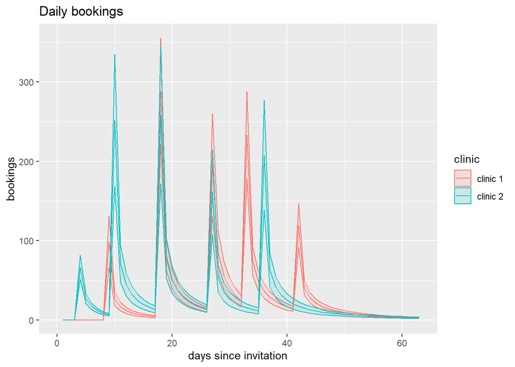

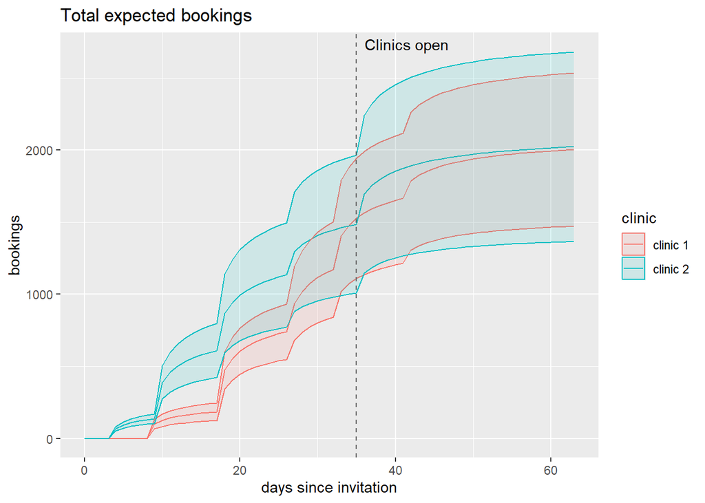

### NPL vs DT

I’ve assumed the two clinics serve distinct but similar populations. I assumed that each clinic did not have overlap in the mailout reach or sign ups from each clinic.

As a result, I decided to do first mailing for clinic 2 with 5000 DT mailings which would give information on conversion rate and time-to-booking to decide waves for clinic 1 for the rest of the scenario.

After that, I looked to balance the number of sign ups for each clinic based on the initial conversion rates provided.

I checked if the clinics could be filled with the assumed conversion rate, and then balanced the number of NPL mailings across the two clinics so both could reach a full capacity.

This led to clinic 1 having 40,000 mailings for NPL and DT, while clinic 2 had 90,000 NPL mailings and 5,000 DT mailings. Based in the assumed conversion rate midpoint, **clinic 1** would have **2200±600 people**, while **clinic 2** would have **2187.5±715**.

### Number of bookings and conversion rate

I’ve projected the number of bookings per wave based on the provided conversion rates. In practice I would update this using a Bayesian approach specific to each clinic and mailing route, updating in response to new information from each wave.

### Time-to-booking

I’ve made assumptions around the time it takes people to respond to mailings and book their appointment, using Weibull distribution curves to determine daily booking volumes. The shape and steepness was chosen so that DT would give a quicker response (under the assumption that communications from GP surgeries carry more weight). The actual shape and slope of the curve is guess work on my part, I assumed most people would book within 5 days for DT and 8 for NPL.

### Timing of waves

I’ve used the plateau point of 80% of predicted bookings on the time-to-book curve to predict the send out date of each successive wave. The first DT wave of mailings for clinic 1 was placed in wave 3 to help ensure enough information would have come through from the test wave of DT at clinic 2.

### Readjusting the plan

I don’t think this current plan would work that well without readjustment. Especially since the width of the estimates are relatively wide.

I’d track conversion rates for each clinic and mailing method using a Bayesian approach, weighting recent data more heavily if rates appear to be shifting. These updated estimates feed into a predicted plateau for each wave. By fitting a new Weibull curve and reading off the asymptote, we can anticipate the final booking count and shift subsequent delivery dates earlier or later accordingly. We may need to define the plateau conservatively given the lag between booking and send, but having 5 waves should give us enough runway to absorb that uncertainty.

### Other assumptions

- **Targetting of particular demographics** has been ignored. If it was, I’d use a random effects model taking in a range of demographic factors, probably from census data.
- The effect of **mailing out too early** on conversion and time-to-booking has been ignored. In practice I’d try to glean this from past data, maybe with an initial regression model with a number of different factors. Then swap that out for a Bayesian approach once mailings have begun.
- **Budgetary constraints** are not a main consideration. I assumed that the cost of mailouts was less that the cost of an empty booking spot. If we needed to balance this I’d look at a newspaper vendor model to decide how to balance costs of empty vs filled spots and how much spend is necessary to fill a spot.
- **No repeat mailings**. I haven’t included the effect of repeat mailings without any data on the potential increase in conversion rates, and since we can’t track address level responses for NPL.
- **No sms/email follow ups.** This was because of no initial data, in reality I’d track conversion rates and booking capacity, then implement sms/email follow if the clinics are not filling from the letters sent pre-opening. If we could see the number of people consenting but not booking, it may be easier to build into the plan earlier and reduce the size of later mailing waves.

# Info provided

## Invitation strategy for a new clinic

### Non-Personalised Letters (NPL)

Sent to households based on address data (Royal Mail PAF). These can be sent multiple times to the same address but we **cannot track responses at address level**.

- Minimum batch size: 4,000 addresses
- Lead time: ~8 days from request to delivery
- Can be sent multiple times to the same address
- Cost: 50p per letter
- ~1.5-3.0% of households book an appointment
- Limited envelope stock: 130,000 available

### DigiTrials (DT)

Personalised letters sent via the NHS to eligible individuals. These are sent **once per person** and the NHS applies eligibility filters before sending.

- NHS filters out ineligible individuals (actual sends may be lower than requested)
- Lead time: ~3 days from request to delivery
- Only sent once to the same address
- Cost £1.50 per letter
- ~2.5-4.0% of individuals invited book an appointment
- Available eligible population in target area:
  - ~40,000 individuals for clinic 1
  - ~5,000 individuals for clinic 2

## Scenario

Two new clinics are **opening in 5 weeks**. The clinics have capacity for:

Week 1–4: Each clinic has capacity for **500 appointments per week** (i.e. 1,000 total per week across both clinics)

Your goal is to ensure the clinics are well-filled across their **first 4 weeks**

Please prepare a short plan outlining:

- How you would approach invitation planning for these clinics
- How you would allocate between NPLs and DigiTrials
- Rough estimates of invitation volumes and timing
- Key assumptions you are making
- How you would monitor performance and adjust your plan